# Simulation-Based Verification for NFL WR 40-yard Dash Extremes

Francis Yap

Overview

This document provides a reproducible simulation-based verification of generalized extreme-value (GEV) modeling for NFL wide receiver (WR) 40-yard dash performance.

The analysis proceeds as follows:

1. NFL Combine WR 40-yard dash times are read from Sports-Reference HTML tables saved with an .xls extension (one file per year).
2. Annual block minima of dash times are computed and analyzed on the negative-time scale (block maxima of -time).
3. GEV and Gumbel models are optionally fit to empirical annual maxima as a diagnostic check.
4. A Monte Carlo study evaluates the finite-sample behavior of GEV return-level estimation, including bias, RMSE, and empirical convergence rates.
5. Return levels are transformed to the speed scale post-estimation, and Delta-method implications are examined.

Packages

```r
suppressPackageStartupMessages({
library(xml2)
library(rvest)
library(dplyr)
library(purrr)
library(extRemes)
library(e1071)
library(ggplot2)
library(tidyr)
library(readr)
library(scales)
})
```

Data input and helper functions

```r
folder_path <- "C:/Users/yapfr/Downloads/NFL Project"

file_list <- list.files(
  path       = folder_path,
  pattern    = "^sportsref_download_\\d{4}\\.xls$",
  full.names = TRUE
)

if (length(file_list) == 0) {
  stop("No files found. Check folder_path and filename pattern.")
}

# Read Sports-Reference HTML disguised as .xls and return the first HTML table

read_sportsref_xls_html <- function(fpath) {
  doc  <- read_html(fpath)
  tabs <- html_table(doc, fill = TRUE)

  if (length(tabs) == 0) stop("No tables found in file: ", fpath)

  tabs[[1]]
}

# Extract year from filename sportsref_download_YYYY.xls

extract_year_from_filename <- function(fpath) {
  as.numeric(gsub(".*_(\\d{4})\\.xls$", "\\1", basename(fpath)))
}

# Robust numeric conversion (handles "", "--", etc.)

to_numeric_quiet <- function(x) suppressWarnings(as.numeric(x))
```

Load WR 40-yard dash times

```r
all_wr_times <- map_dfr(file_list, function(fpath) {
yr <- extract_year_from_filename(fpath)
df <- read_sportsref_xls_html(fpath)

df %>%
filter(.data$Pos == "WR") %>%
mutate(time_40 = to_numeric_quiet(.data$`40yd`)) %>%
filter(!is.na(.data$time_40)) %>%
transmute(year = yr, time_40)
})

print(head(all_wr_times, 20))
```

```
## # A tibble: 20 × 2
##     year time_40
##    <dbl>   <dbl>
##  1  2000    4.59
##  2  2000    4.54
##  3  2000    4.37
##  4  2000    4.61
##  5  2000    4.41
##  6  2000    4.74
##  7  2000    4.54
##  8  2000    4.55
##  9  2000    4.58
## 10  2000    4.51
## 11  2000    4.58
## 12  2000    4.43
## 13  2000    4.55
## 14  2000    4.56
## 15  2000    4.66
## 16  2000    4.52
## 17  2000    4.54
## 18  2000    4.5
## 19  2000    4.54
## 20  2000    4.7
```

```r
cat("\nTotal rows:", nrow(all_wr_times), "\n")
```

```
##
## Total rows: 1128
```

```r
summary(all_wr_times$time_40)
```

```
##    Min. 1st Qu.  Median    Mean 3rd Qu.    Max.
##   4.210   4.430   4.510   4.507   4.570   4.850
```

Parent distribution calibration

```r
mu_T  <- mean(all_wr_times$time_40, na.rm = TRUE)
sd_T  <- sd(all_wr_times$time_40,   na.rm = TRUE)
var_T <- var(all_wr_times$time_40,  na.rm = TRUE)

counts <- as.numeric(table(all_wr_times$year))

skew_T <- e1071::skewness(all_wr_times$time_40, na.rm = TRUE)
k      <- 8 / (skew_T^2)

cat("\nEmpirical parent moments (time scale):\n")
```

```
##
## Empirical parent moments (time scale):
```

```r
print(c(mu_T = mu_T, sd_T = sd_T, var_T = var_T))
```

```
##       mu_T       sd_T      var_T
## 4.50725177 0.10173944 0.01035091
```

```r
cat("\nPer-year WR counts summary:\n")
```

```
##
## Per-year WR counts summary:
```

```r
print(summary(counts))
```

```
##    Min. 1st Qu.  Median    Mean 3rd Qu.    Max.
##   30.00   39.00   44.00   43.38   46.75   60.00
```

```r
cat("Median:", median(counts), " SD:", sd(counts), " Var:", var(counts), "\n")
```

```
## Median: 44  SD: 6.542641  Var: 42.80615
```

```r
cat("\nSkewness(time_40):", skew_T, "\n")
```

```
##
## Skewness(time_40): 0.151872
```

```r
cat("k = 8 / skew^2:", k, "\n")
```

```
## k = 8 / skew^2: 346.8445
```

Fixed calibration for reproducibility

For the Monte Carlo study, the parent distribution is fixed to the calibration reported in the manuscript to ensure reproducibility.

```r
freeze_parent <- TRUE

if (isTRUE(freeze_parent)) {
mu_T       <- 4.5072520
sd_T       <- 0.1017394
n_per_year <- 44L
} else {
n_per_year <- as.integer(median(counts))
}

cat("\nParent parameters used in Monte Carlo:\n")
```

```
##
## Parent parameters used in Monte Carlo:
```

```r
print(c(mu_T = mu_T, sd_T = sd_T, n_per_year = n_per_year))
```

```
##       mu_T       sd_T n_per_year
##  4.5072520  0.1017394 44.0000000
```

Empirical annual maxima

Annual block minima of time correspond to block maxima of -time. We also track maxima on the speed scale.

```r
annual_maxima <- map_dfr(file_list, function(fpath) {
yr <- extract_year_from_filename(fpath)
df <- read_sportsref_xls_html(fpath)

wr <- df %>%
filter(.data$Pos == "WR") %>%
mutate(time_40 = to_numeric_quiet(.data$`40yd`)) %>%
filter(!is.na(.data$time_40))

if (nrow(wr) == 0) {
return(tibble(year = yr, max_neg_time = NA_real_, max_speed = NA_real_))
}

tibble(
year         = yr,
max_neg_time = max(-wr$time_40,      na.rm = TRUE),
max_speed    = max(40 / wr$time_40,  na.rm = TRUE)
)
}) %>%
arrange(year)

print(head(annual_maxima, 20))
```

```
## # A tibble: 20 × 3
##     year max_neg_time max_speed
##    <dbl>        <dbl>     <dbl>
##  1  2000        -4.34      9.22
##  2  2001        -4.31      9.28
##  3  2002        -4.22      9.48
##  4  2003        -4.34      9.22
##  5  2004        -4.33      9.24
##  6  2005        -4.28      9.35
##  7  2006        -4.32      9.26
##  8  2007        -4.3       9.30
##  9  2008        -4.33      9.24
## 10  2009        -4.3       9.30
## 11  2010        -4.28      9.35
## 12  2011        -4.31      9.28
## 13  2012        -4.31      9.28
## 14  2013        -4.27      9.37
## 15  2014        -4.26      9.39
## 16  2015        -4.28      9.35
## 17  2016        -4.32      9.26
## 18  2017        -4.22      9.48
## 19  2018        -4.34      9.22
## 20  2019        -4.31      9.28
```

Optional GEV vs Gumbel diagnostic fits

```r
gev_neg <- fevd(x = annual_maxima$max_neg_time, type = "GEV",    method = "MLE")
gum_neg <- fevd(x = annual_maxima$max_neg_time, type = "Gumbel", method = "MLE")

gev_speed <- fevd(x = annual_maxima$max_speed, type = "GEV",    method = "MLE")
gum_speed <- fevd(x = annual_maxima$max_speed, type = "Gumbel", method = "MLE")

cat("\n--- Empirical fits: -time scale ---\n")
```

```
##
## --- Empirical fits: -time scale ---
```

```r
print(summary(gev_neg))
```

```
##
## fevd(x = annual_maxima$max_neg_time, type = "GEV", method = "MLE")
##
## [1] "Estimation Method used: MLE"
##
##
##  Negative Log-Likelihood Value:  -51.28845
##
##
##  Estimated parameters:
##    location       scale       shape
## -4.31067757  0.02768675  0.05407239
##
##  Standard Error Estimates:
##    location       scale       shape
## 0.006537516 0.005025388 0.211313360
##
##  Estimated parameter covariance matrix.
##               location         scale         shape
## location  4.273911e-05  1.710152e-05 -0.0006517249
## scale     1.710152e-05  2.525453e-05 -0.0004643856
## shape    -6.517249e-04 -4.643856e-04  0.0446533361
##
##  AIC = -96.57691
##
##  BIC = -92.80262
## $par
##    location       scale       shape
## -4.31067757  0.02768675  0.05407239
##
## $cov.theta
##               location         scale         shape
## location  4.273911e-05  1.710152e-05 -0.0006517249
## scale     1.710152e-05  2.525453e-05 -0.0004643856
## shape    -6.517249e-04 -4.643856e-04  0.0446533361
##
## $se.theta
##    location       scale       shape
## 0.006537516 0.005025388 0.211313360
##
## $nllh
## [1] -51.28845
##
## $AIC
## [1] -96.57691
##
## $BIC
## [1] -92.80262
```

```r
print(summary(gum_neg))
```

```
##
## fevd(x = annual_maxima$max_neg_time, type = "Gumbel", method = "MLE")
##
## [1] "Estimation Method used: MLE"
##
##
##  Negative Log-Likelihood Value:  -51.25367
##
##
##  Estimated parameters:
##    location       scale
## -4.30985768  0.02834444
##
##  Standard Error Estimates:
##    location       scale
## 0.005851324 0.004463687
##
##  Estimated parameter covariance matrix.
##              location        scale
## location 3.423799e-05 8.162694e-06
## scale    8.162694e-06 1.992450e-05
##
##  AIC = -98.50734
##
##  BIC = -95.99114
## $par
##    location       scale
## -4.30985768  0.02834444
##
## $cov.theta
##              location        scale
## location 3.423799e-05 8.162694e-06
## scale    8.162694e-06 1.992450e-05
##
## $se.theta
##    location       scale
## 0.005851324 0.004463687
##
## $nllh
## [1] -51.25367
##
## $AIC
## [1] -98.50734
##
## $BIC
## [1] -95.99114
```

```r
cat("\n--- Empirical fits: speed scale ---\n")
```

```
##
## --- Empirical fits: speed scale ---
```

```r
print(summary(gev_speed))
```

```
##
## fevd(x = annual_maxima$max_speed, type = "GEV", method = "MLE")
##
## [1] "Estimation Method used: MLE"
##
##
##  Negative Log-Likelihood Value:  -31.14483
##
##
##  Estimated parameters:
##   location      scale      shape
## 9.27916314 0.05952814 0.07100680
##
##  Standard Error Estimates:
##   location      scale      shape
## 0.01408154 0.01091107 0.21329023
##
##  Estimated parameter covariance matrix.
##               location         scale         shape
## location  1.982899e-04  8.224531e-05 -0.0014147091
## scale     8.224531e-05  1.190514e-04 -0.0009913018
## shape    -1.414709e-03 -9.913018e-04  0.0454927231
##
##  AIC = -56.28966
##
##  BIC = -52.51537
## $par
##   location      scale      shape
## 9.27916314 0.05952814 0.07100680
##
## $cov.theta
##               location         scale         shape
## location  1.982899e-04  8.224531e-05 -0.0014147091
## scale     8.224531e-05  1.190514e-04 -0.0009913018
## shape    -1.414709e-03 -9.913018e-04  0.0454927231
##
## $se.theta
##   location      scale      shape
## 0.01408154 0.01091107 0.21329023
##
## $nllh
## [1] -31.14483
##
## $AIC
## [1] -56.28966
##
## $BIC
## [1] -52.51537
```

```r
print(summary(gum_speed))
```

```
##
## fevd(x = annual_maxima$max_speed, type = "Gumbel", method = "MLE")
##
## [1] "Estimation Method used: MLE"
##
##
##  Negative Log-Likelihood Value:  -31.08477
##
##
##  Estimated parameters:
##   location      scale
## 9.28148762 0.06141999
##
##  Standard Error Estimates:
##    location       scale
## 0.012674187 0.009714425
##
##  Estimated parameter covariance matrix.
##              location        scale
## location 1.606350e-04 3.830538e-05
## scale    3.830538e-05 9.437005e-05
##
##  AIC = -58.16955
##
##  BIC = -55.65336
## $par
##   location      scale
## 9.28148762 0.06141999
##
## $cov.theta
##              location        scale
## location 1.606350e-04 3.830538e-05
## scale    3.830538e-05 9.437005e-05
##
## $se.theta
##    location       scale
## 0.012674187 0.009714425
##
## $nllh
## [1] -31.08477
##
## $AIC
## [1] -58.16955
##
## $BIC
## [1] -55.65336
```

Diagnostic plots

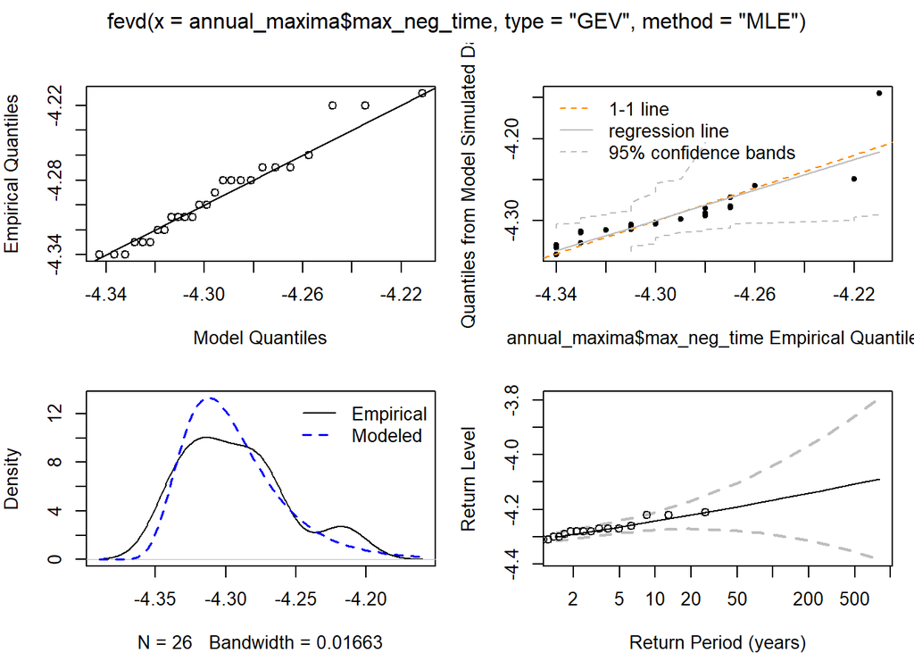

```r
par(mar = c(4, 4, 2, 1))
plot(gev_neg)
```

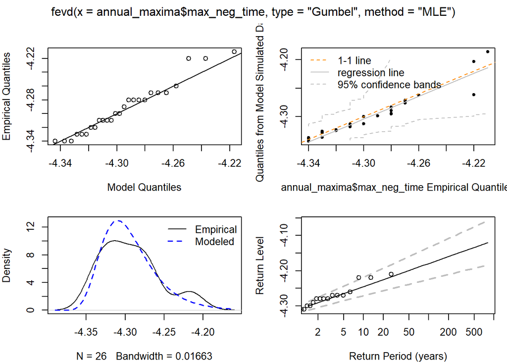

```r
plot(gum_neg)
```

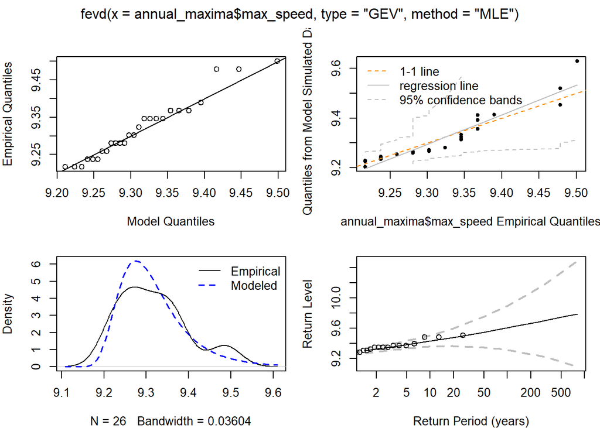

```r
plot(gev_speed)
```

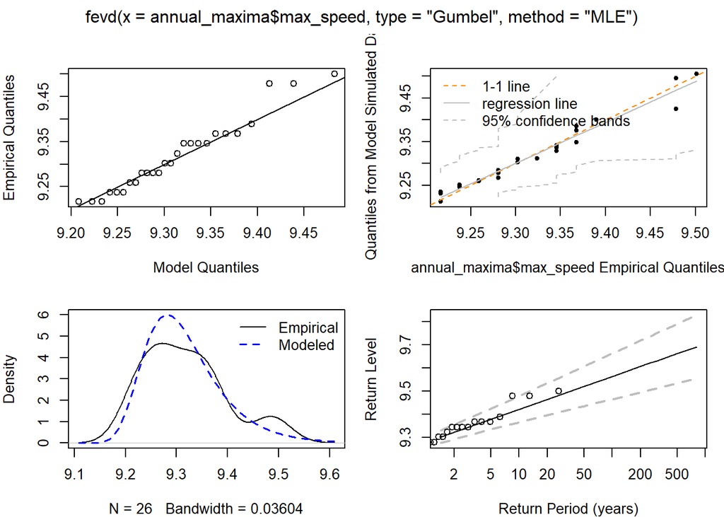

```r
plot(gum_speed)
```

Likelihood-ratio tests (xi = 0 vs free xi)

```r
ll_gev_neg <- -gev_neg$results$value
ll_gum_neg <- -gum_neg$results$value
LRT_neg    <- 2 * (ll_gev_neg - ll_gum_neg)
pval_neg   <- 1 - pchisq(LRT_neg, df = 1)

ll_gev_speed <- -gev_speed$results$value
ll_gum_speed <- -gum_speed$results$value
LRT_speed    <- 2 * (ll_gev_speed - ll_gum_speed)
pval_speed   <- 1 - pchisq(LRT_speed, df = 1)

cat("\nLRT (xi=0 vs free):\n")
```

```
##
## LRT (xi=0 vs free):
```

```r
print(c(LRT_neg = LRT_neg, pval_neg = pval_neg, LRT_speed = LRT_speed, pval_speed = pval_speed))
```

```
##    LRT_neg   pval_neg  LRT_speed pval_speed
## 0.06956991 0.79196402 0.12011430 0.72891055
```

Monte Carlo simulation

```r
set.seed(20251122)

years_grid <- c(5, 10, 15, 20, 25, 26, 30, 35, 40, 45, 50, 55, 60, 65, 70, 75,
80, 85, 90, 95, 100)

n_sim   <- 1000
periods <- years_grid
```

Simulation helper functions (parallel to the R script)

```r
simulate_block_maxima_normal <- function(n_years, n_per_year, mu_T, sd_T) {
times <- rnorm(n_years * n_per_year, mean = mu_T, sd = sd_T)
mat   <- matrix(times, nrow = n_years, ncol = n_per_year, byrow = TRUE)

year_min_time <- apply(mat, 1, min)   # annual minima of time
neg_time      <- -year_min_time       # annual maxima on -time scale

list(neg_time = neg_time)
}

fit_gev_and_RL <- function(x, periods) {
tryCatch({
fit <- suppressWarnings(fevd(x, type = "GEV"))
rl  <- suppressWarnings(return.level(fit, return.period = periods, do.ci = FALSE))

pars <- fit$results$par
list(
  mu    = unname(pars["location"]),
  sigma = unname(pars["scale"]),
  xi    = unname(pars["shape"]),
  RL    = as.numeric(rl)
)

}, error = function(e) {
list(
mu    = NA_real_,
sigma = NA_real_,
xi    = NA_real_,
RL    = rep(NA_real_, length(periods))
)
})
}

simulate_once <- function(sim_id, n_years, n_per_year, mu_T, sd_T, periods) {
sim <- simulate_block_maxima_normal(
n_years    = n_years,
n_per_year = n_per_year,
mu_T       = mu_T,
sd_T       = sd_T
)

fit_neg <- fit_gev_and_RL(sim$neg_time, periods = periods)

# Transform RLs to speed AFTER estimation

RL_speed <- 40 / (-fit_neg$RL)

tibble(
sim_id    = sim_id,
years     = n_years,
mu_hat    = fit_neg$mu,
sigma_hat = fit_neg$sigma,
xi_hat    = fit_neg$xi,
RL_period = periods,
RL_neg    = fit_neg$RL,
RL_speed  = RL_speed
)
}
```

Monte Carlo execution

```r
results_long <- map_dfr(years_grid, function(n_years) {
message("Simulating for n = ", n_years, " years ...")
map_dfr(seq_len(n_sim), function(s) {
simulate_once(
sim_id     = s,
n_years    = n_years,
n_per_year = n_per_year,
mu_T       = mu_T,
sd_T       = sd_T,
periods    = periods
)
})
})
```

```
## Simulating for n = 5 years ...
```

```
## Simulating for n = 10 years ...
```

```
## Simulating for n = 15 years ...
```

```
## Simulating for n = 20 years ...
```

```
## Simulating for n = 25 years ...
```

```
## Simulating for n = 26 years ...
```

```
## Simulating for n = 30 years ...
```

```
## Simulating for n = 35 years ...
```

```
## Simulating for n = 40 years ...
```

```
## Simulating for n = 45 years ...
```

```
## Simulating for n = 50 years ...
```

```
## Simulating for n = 55 years ...
```

```
## Simulating for n = 60 years ...
```

```
## Simulating for n = 65 years ...
```

```
## Simulating for n = 70 years ...
```

```
## Simulating for n = 75 years ...
```

```
## Simulating for n = 80 years ...
```

```
## Simulating for n = 85 years ...
```

```
## Simulating for n = 90 years ...
```

```
## Simulating for n = 95 years ...
```

```
## Simulating for n = 100 years ...
```

```r
dplyr::glimpse(results_long)
```

```
## Rows: 441,000
## Columns: 8
## $ sim_id    <int> 1, 1, 1, 1, 1, 1, 1, 1, 1, 1, 1, 1, 1, 1, 1, 1, 1, 1, 1, 1, …
## $ years     <dbl> 5, 5, 5, 5, 5, 5, 5, 5, 5, 5, 5, 5, 5, 5, 5, 5, 5, 5, 5, 5, …
## $ mu_hat    <dbl> -4.31893, -4.31893, -4.31893, -4.31893, -4.31893, -4.31893, …
## $ sigma_hat <dbl> 0.009776472, 0.009776472, 0.009776472, 0.009776472, 0.009776…
## $ xi_hat    <dbl> 1.103134, 1.103134, 1.103134, 1.103134, 1.103134, 1.103134, …
## $ RL_period <dbl> 5, 10, 15, 20, 25, 26, 30, 35, 40, 45, 50, 55, 60, 65, 70, 7…
## $ RL_neg    <dbl> -4.281432, -4.221704, -4.158551, -4.093084, -4.025851, -4.01…
## $ RL_speed  <dbl> 9.342669, 9.474848, 9.618736, 9.772583, 9.935788, 9.969534, …
```

```r
nf_counts <- results_long %>%
summarise(
n_bad_RL_neg   = sum(!is.finite(RL_neg)),
n_bad_RL_speed = sum(!is.finite(RL_speed)),
n_bad_mu       = sum(!is.finite(mu_hat)),
n_bad_sigma    = sum(!is.finite(sigma_hat)),
n_bad_xi       = sum(!is.finite(xi_hat))
)

cat("\nNon-finite counts:\n")
```

```
##
## Non-finite counts:
```

```r
print(nf_counts)
```

```
## # A tibble: 1 × 5
##   n_bad_RL_neg n_bad_RL_speed n_bad_mu n_bad_sigma n_bad_xi
##          <int>          <int>    <int>       <int>    <int>
## 1            0              0        0           0        0
```

Boxplot diagnostics (zoomed)

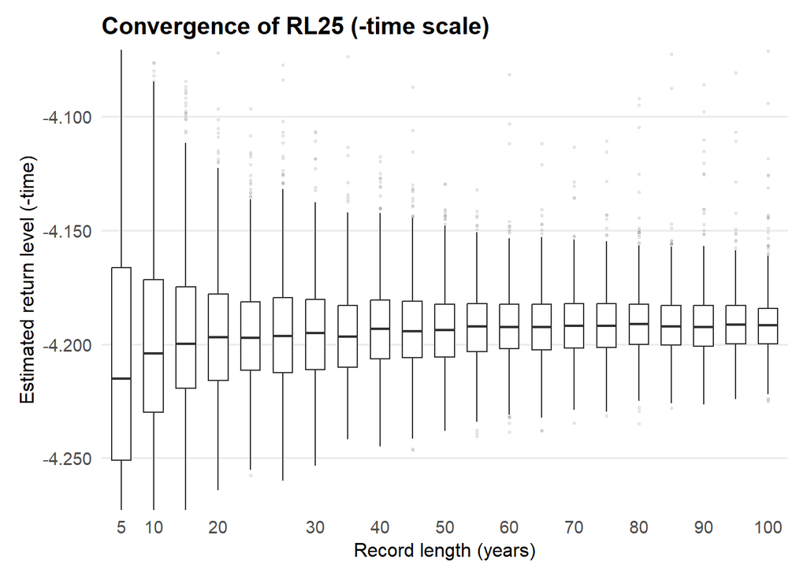

```r
plot_RL_box_zoom <- function(df_long,
RLp,
which_scale = c("neg", "speed"),
zoom_prob = 0.99,
x_breaks = c(5, 10, 20, 30, 40, 50, 60, 70, 80, 90, 100)) {
which_scale <- match.arg(which_scale)

dfp <- df_long %>%
filter(RL_period == RLp) %>%
mutate(RL_value = if (which_scale == "neg") RL_neg else RL_speed) %>%
filter(is.finite(RL_value))

if (nrow(dfp) == 0) stop("No finite values for RL", RLp, " on scale ", which_scale)

y_lo <- quantile(dfp$RL_value, 1 - zoom_prob, na.rm = TRUE)
y_hi <- quantile(dfp$RL_value, zoom_prob,     na.rm = TRUE)

scale_label <- if (which_scale == "neg") "-time" else "speed"

ggplot(dfp, aes(x = factor(years), y = RL_value)) +
geom_boxplot(
width         = 0.6,
linewidth     = 0.4,
outlier.alpha = 0.10,
outlier.size  = 0.5
) +
coord_cartesian(ylim = c(y_lo, y_hi)) +
scale_x_discrete(breaks = as.character(x_breaks)) +
scale_y_continuous(labels = scales::label_number(accuracy = 0.005)) +
labs(
title = paste0("Convergence of RL", RLp, " (", scale_label, " scale)"),
x     = "Record length (years)",
y     = paste0("Estimated return level (", scale_label, ")")
) +
theme_minimal(base_size = 14) +
theme(
panel.grid.minor   = element_blank(),
panel.grid.major.x = element_blank(),
axis.text.x        = element_text(size = 11),
axis.text.y        = element_text(size = 11),
axis.title         = element_text(size = 12),
plot.title         = element_text(face = "bold", size = 15),
plot.margin        = margin(10, 12, 10, 12)
)
}

plot_RL_box_zoom(results_long, RLp = 25, which_scale = "neg")
```

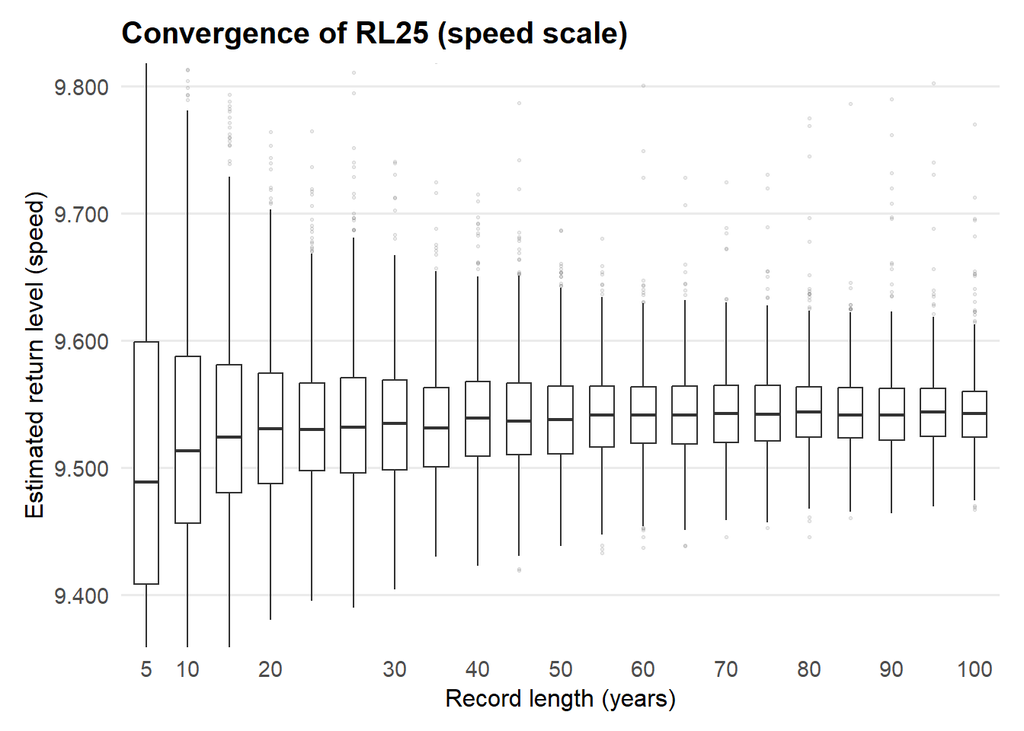

```r
plot_RL_box_zoom(results_long, RLp = 25, which_scale = "speed")
```

“Truth” via long-run simulation

```r
years_true <- 100000

sim_true <- simulate_block_maxima_normal(
n_years    = years_true,
n_per_year = n_per_year,
mu_T       = mu_T,
sd_T       = sd_T
)

fit_true <- fit_gev_and_RL(sim_true$neg_time, periods = periods)

true_pars_neg <- c(mu = fit_true$mu, sigma = fit_true$sigma, xi = fit_true$xi)
true_RL_neg   <- fit_true$RL
true_RL_speed <- 40 / (-true_RL_neg)

cat("\nApproximate 'truth' parameters on -time scale (long-run fit):\n")
```

```
##
## Approximate 'truth' parameters on -time scale (long-run fit):
```

```r
print(true_pars_neg)
```

```
##          mu       sigma          xi
## -4.30376738  0.04274993 -0.11487908
```

```r
truth_tbl <- tibble(
RL_period  = periods,
true_neg   = true_RL_neg,
true_speed = true_RL_speed
)

print(truth_tbl)
```

```
## # A tibble: 21 × 3
##    RL_period true_neg true_speed
##        <dbl>    <dbl>      <dbl>
##  1         5    -4.24       9.42
##  2        10    -4.22       9.48
##  3        15    -4.21       9.51
##  4        20    -4.20       9.53
##  5        25    -4.19       9.55
##  6        26    -4.19       9.55
##  7        30    -4.18       9.56
##  8        35    -4.18       9.57
##  9        40    -4.18       9.58
## 10        45    -4.17       9.59
## # ℹ 11 more rows
```

Bias/RMSE summaries

```r
bias_rmse_all <- results_long %>%
left_join(truth_tbl, by = "RL_period") %>%
mutate(
err_neg   = RL_neg   - true_neg,
err_speed = RL_speed - true_speed
) %>%
group_by(RL_period, years) %>%
summarise(
bias_neg   = mean(err_neg,   na.rm = TRUE),
rmse_neg   = sqrt(mean(err_neg^2,   na.rm = TRUE)),
sd_neg     = sd(RL_neg,      na.rm = TRUE),
bias_speed = mean(err_speed, na.rm = TRUE),
rmse_speed = sqrt(mean(err_speed^2, na.rm = TRUE)),
sd_speed   = sd(RL_speed,    na.rm = TRUE),
.groups    = "drop"
)

print(head(bias_rmse_all, 30))
```

```
## # A tibble: 30 × 8
##    RL_period years   bias_neg rmse_neg sd_neg  bias_speed rmse_speed sd_speed
##        <dbl> <dbl>      <dbl>    <dbl>  <dbl>       <dbl>      <dbl>    <dbl>
##  1         5     5 -0.0125      0.0384 0.0363 -0.0271         0.0845   0.0800
##  2         5    10 -0.00364     0.0219 0.0216 -0.00783        0.0486   0.0480
##  3         5    15 -0.00209     0.0175 0.0174 -0.00448        0.0388   0.0386
##  4         5    20 -0.00165     0.0157 0.0156 -0.00352        0.0349   0.0348
##  5         5    25 -0.00162     0.0135 0.0134 -0.00350        0.0300   0.0298
##  6         5    26 -0.00156     0.0134 0.0134 -0.00337        0.0299   0.0297
##  7         5    30 -0.00120     0.0128 0.0128 -0.00259        0.0285   0.0284
##  8         5    35 -0.00126     0.0142 0.0142 -0.00270        0.0319   0.0318
##  9         5    40 -0.000626    0.0124 0.0124 -0.00131        0.0277   0.0276
## 10         5    45 -0.0000521   0.0149 0.0149  0.00000244     0.0336   0.0336
## # ℹ 20 more rows
```

Bias and RMSE plots

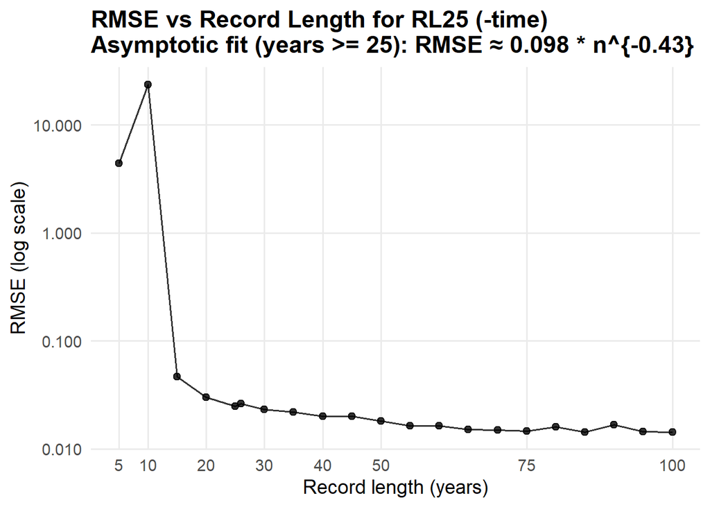

```r
plot_rmse_clean <- function(df_bias_rmse, RLp, which_scale = c("neg", "speed"),
n_min_rate = 25,
x_breaks = c(5, 10, 20, 30, 40, 50, 75, 100),
r2_min = 0.50) {
which_scale <- match.arg(which_scale)
dfp <- df_bias_rmse %>% dplyr::filter(RL_period == RLp)

rmse_col    <- if (which_scale == "neg") "rmse_neg" else "rmse_speed"
scale_label <- if (which_scale == "neg") "-time" else "speed"

dfp <- dfp %>% dplyr::mutate(rmse_plot = .data[[rmse_col]])

df_rate <- dfp %>%
dplyr::filter(years >= n_min_rate, is.finite(rmse_plot), rmse_plot > 0)

fit   <- lm(log(rmse_plot) ~ log(years), data = df_rate)
alpha <- -coef(fit)[["log(years)"]]
C     <- exp(coef(fit)[["(Intercept)"]])
r2    <- summary(fit)$r.squared

fit_label <- if (is.finite(alpha) && alpha > 0 && is.finite(r2) && r2 >= r2_min) {
paste0(
"Asymptotic fit (years >= ", n_min_rate, "): RMSE ≈ ",
sprintf("%.3g", C), " * n^{-", sprintf("%.2f", alpha), "}"
)
} else {
paste0(
"No clear power-law decay (years >= ", n_min_rate, "): ",
"alpha = ", sprintf("%.2f", alpha), ", R^2 = ", sprintf("%.2f", r2)
)
}

ggplot(dfp, aes(x = years, y = rmse_plot)) +
geom_line(linewidth = 0.6, alpha = 0.8) +
geom_point(size = 2, alpha = 0.8) +
scale_y_log10(
labels = scales::label_number(accuracy = 0.001),
breaks = scales::log_breaks(n = 6)
) +
scale_x_continuous(breaks = x_breaks) +
labs(
title = paste0("RMSE vs Record Length for RL", RLp, " (", scale_label, ")\n", fit_label),
x = "Record length (years)",
y = "RMSE (log scale)"
) +
theme_minimal(base_size = 14) +
theme(
panel.grid.minor = element_blank(),
plot.title = element_text(face = "bold")
)
}

plot_bias_clean <- function(df_bias_rmse, RLp, which_scale = c("neg", "speed"),
x_breaks = c(5, 10, 20, 30, 40, 50, 75, 100)) {
which_scale <- match.arg(which_scale)
dfp <- df_bias_rmse %>% dplyr::filter(RL_period == RLp)

bias_col    <- if (which_scale == "neg") "bias_neg" else "bias_speed"
scale_label <- if (which_scale == "neg") "-time" else "speed"

dfp <- dfp %>% dplyr::mutate(bias_plot = .data[[bias_col]])

ggplot(dfp, aes(x = years, y = bias_plot)) +
geom_hline(yintercept = 0, linetype = "dashed", color = "grey50") +
geom_line(linewidth = 0.6, alpha = 0.8) +
geom_point(size = 2, alpha = 0.8) +
scale_x_continuous(breaks = x_breaks) +
scale_y_continuous(labels = scales::label_number(accuracy = 0.01)) +
labs(
title = paste0("Bias vs Record Length for RL", RLp, " (", scale_label, ")"),
x = "Record length (years)",
y = "Bias"
) +
theme_minimal(base_size = 14) +
theme(
panel.grid.minor = element_blank(),
plot.title = element_text(face = "bold")
)
}

plot_rmse_clean(bias_rmse_all, RLp = 25, which_scale = "neg")
```

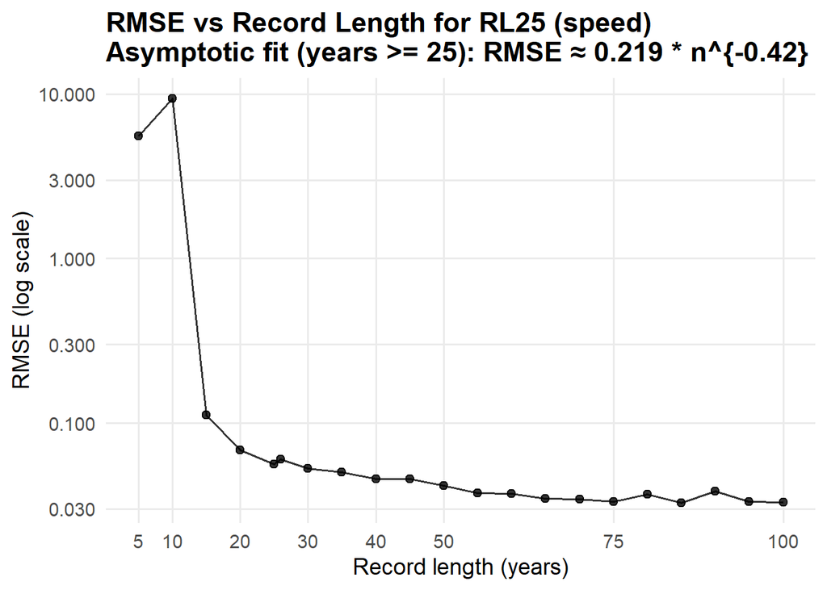

```r
plot_rmse_clean(bias_rmse_all, RLp = 25, which_scale = "speed")
```

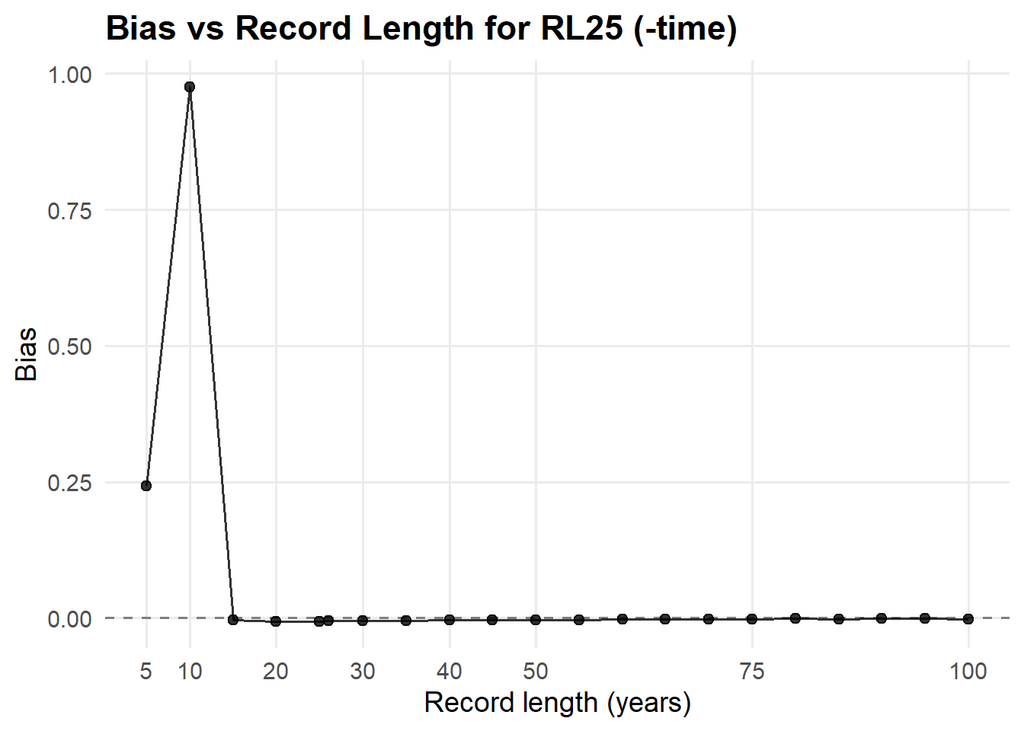

```r
plot_bias_clean(bias_rmse_all, RLp = 25, which_scale = "neg")
```

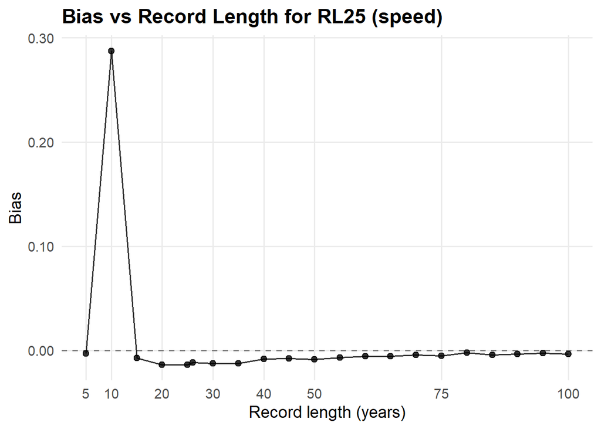

```r
plot_bias_clean(bias_rmse_all, RLp = 25, which_scale = "speed")
```

Convergence-rate and Delta-method table

```r
estimate_rate_and_constant <- function(df_bias_rmse,
which_scale = c("neg", "speed"),
n_min_rate = 25,
min_points = 4) {
which_scale <- match.arg(which_scale)
rmse_col <- if (which_scale == "neg") "rmse_neg" else "rmse_speed"

df2 <- df_bias_rmse %>%
mutate(rmse_tmp = .data[[rmse_col]]) %>%
filter(years >= n_min_rate, is.finite(rmse_tmp), rmse_tmp > 0)

df2 %>%
group_by(RL_period) %>%
group_modify(~{
dat <- .x
if (nrow(dat) < min_points) {
return(tibble(alpha = NA_real_, C = NA_real_, r2 = NA_real_, n_used = nrow(dat)))
}
fit <- lm(log(rmse_tmp) ~ log(years), data = dat)
tibble(
alpha  = -coef(fit)[["log(years)"]],
C      = exp(coef(fit)[["(Intercept)"]]),
r2     = summary(fit)$r.squared,
n_used = nrow(dat)
)
}) %>%
ungroup()
}

rate_neg   <- estimate_rate_and_constant(bias_rmse_all, which_scale = "neg",   n_min_rate = 25)
rate_speed <- estimate_rate_and_constant(bias_rmse_all, which_scale = "speed", n_min_rate = 25)

rate_summary <- rate_neg %>%
rename(alpha_neg = alpha, C_neg = C, r2_neg = r2, n_used_neg = n_used) %>%
left_join(
rate_speed %>%
rename(alpha_speed = alpha, C_speed = C, r2_speed = r2, n_used_speed = n_used),
by = "RL_period"
) %>%
mutate(
C_ratio     = C_speed / C_neg,
RL_neg_true = true_RL_neg[match(RL_period, periods)],
infl_theory = 40 / (RL_neg_true^2),

ratio_over_theory     = C_ratio / infl_theory,
alpha_theory          = 0.5,
alpha_neg_diff        = alpha_neg - alpha_theory,
alpha_speed_diff      = alpha_speed - alpha_theory,
alpha_neg_ratio       = alpha_neg / alpha_theory,
alpha_speed_ratio     = alpha_speed / alpha_theory,
alpha_speed_minus_neg = alpha_speed - alpha_neg,
alpha_speed_over_neg  = alpha_speed / alpha_neg

) %>%
arrange(RL_period)

print(rate_summary, n = nrow(rate_summary))
```

```
## # A tibble: 21 × 20
##    RL_period alpha_neg  C_neg r2_neg n_used_neg alpha_speed C_speed r2_speed
##        <dbl>     <dbl>  <dbl>  <dbl>      <int>       <dbl>   <dbl>    <dbl>
##  1         5   -0.0469 0.0111 0.0246         17     -0.0658  0.0231   0.0445
##  2        10    0.159  0.0263 0.312          17      0.144   0.0562   0.257
##  3        15    0.290  0.0485 0.700          17      0.279   0.106    0.666
##  4        20    0.372  0.0732 0.848          17      0.364   0.162    0.831
##  5        25    0.426  0.0980 0.908          17      0.421   0.219    0.898
##  6        26    0.435  0.103  0.915          17      0.430   0.230    0.906
##  7        30    0.465  0.122  0.936          17      0.461   0.276    0.929
##  8        35    0.494  0.145  0.951          17      0.492   0.331    0.945
##  9        40    0.517  0.167  0.959          17      0.517   0.384    0.955
## 10        45    0.535  0.188  0.964          17      0.537   0.436    0.960
## 11        50    0.551  0.208  0.967          17      0.554   0.486    0.963
## 12        55    0.564  0.227  0.969          17      0.569   0.536    0.964
## 13        60    0.576  0.246  0.971          17      0.582   0.584    0.965
## 14        65    0.586  0.264  0.971          17      0.594   0.632    0.965
## 15        70    0.595  0.281  0.971          17      0.605   0.679    0.965
## 16        75    0.603  0.298  0.971          17      0.615   0.726    0.964
## 17        80    0.611  0.315  0.971          17      0.625   0.773    0.963
## 18        85    0.618  0.331  0.971          17      0.633   0.820    0.961
## 19        90    0.625  0.347  0.970          17      0.642   0.867    0.960
## 20        95    0.631  0.363  0.970          17      0.650   0.914    0.958
## 21       100    0.636  0.378  0.969          17      0.657   0.961    0.957
## # ℹ 12 more variables: n_used_speed <int>, C_ratio <dbl>, RL_neg_true <dbl>,
## #   infl_theory <dbl>, ratio_over_theory <dbl>, alpha_theory <dbl>,
## #   alpha_neg_diff <dbl>, alpha_speed_diff <dbl>, alpha_neg_ratio <dbl>,
## #   alpha_speed_ratio <dbl>, alpha_speed_minus_neg <dbl>,
## #   alpha_speed_over_neg <dbl>
```

Write LaTeX table rows (robust in Knit AND interactive R)

```r
is_knitting <- isTRUE(getOption("knitr.in.progress"))

# Decide output directory
out_dir <- if (is_knitting) {
  # When knitting: write next to the Rmd so LaTeX \input finds it reliably
  tryCatch(
    normalizePath(dirname(knitr::current_input()), winslash = "/", mustWork = FALSE),
    error = function(e) normalizePath(getwd(), winslash = "/", mustWork = FALSE)
  )
} else {
  # When running interactively: write to your project/data folder
  normalizePath(folder_path, winslash = "/", mustWork = FALSE)
}

# Fallback if folder_path doesn't exist (avoid accidental OneDrive surprises)
if (!dir.exists(out_dir)) {
  warning("Output directory does not exist: ", out_dir,
          "\nFalling back to current working directory: ", getwd())
  out_dir <- normalizePath(getwd(), winslash = "/", mustWork = FALSE)
}

out_tex <- file.path(out_dir, "rate_summary_rows_with_bottomrule.tex")

# Build the table
rate_tbl <- rate_summary %>%
  dplyr::transmute(
    p        = RL_period,
    alpha_mT = alpha_neg,
    C_mT     = C_neg,
    R2_mT    = r2_neg,
    alpha_V  = alpha_speed,
    C_V      = C_speed,
    R2_V     = r2_speed,
    ratio_C  = C_ratio,
    infl_th  = infl_theory
  ) %>%
  dplyr::arrange(p)

fmt <- function(x, d = 3) ifelse(is.na(x), "", formatC(x, format = "f", digits = d))

rate_tbl_fmt <- rate_tbl %>%
  dplyr::mutate(
    alpha_mT = fmt(alpha_mT, 3),
    C_mT     = fmt(C_mT, 3),
    R2_mT    = fmt(R2_mT, 3),
    alpha_V  = fmt(alpha_V, 3),
    C_V      = fmt(C_V, 3),
    R2_V     = fmt(R2_V, 3),
    ratio_C  = fmt(ratio_C, 3),
    infl_th  = fmt(infl_th, 3)
  )

lines <- apply(rate_tbl_fmt, 1, function(r) {
  paste0(
    r[["p"]], " & ",
    r[["alpha_mT"]], " & ", r[["C_mT"]], " & ", r[["R2_mT"]], " & ",
    r[["alpha_V"]],  " & ", r[["C_V"]],  " & ", r[["R2_V"]],  " & ",
    r[["ratio_C"]],  " & ", r[["infl_th"]], " \\\\"
  )
})

# Put \bottomrule INSIDE the file (since LaTeX tabular expects it there if you omit it outside)
lines <- c(lines, "\\bottomrule")

# Binary write (prevents BOM/encoding/control-char issues that can break booktabs)
con <- file(out_tex, open = "wb")
writeBin(charToRaw(paste(lines, collapse = "\n")), con)
close(con)

message("Wrote: ", normalizePath(out_tex, winslash = "/", mustWork = FALSE))
```

```
## Wrote: C:/Users/yapfr/Downloads/NFL Project/rate_summary_rows_with_bottomrule.tex
```